# **Example Rmarkdown report**

# Code chunks

Code chunks ae created by entering code between delimiters `` ```{r} `` and `` ``` ``

There are a number of options around running and displaying code chunks that can be applied globally or locally.

# Global options and chunk options

- include = FALSE prevents code and results from appearing in the finished file. R Markdown still runs the code in the chunk, and the results can be used by other chunks
- echo = FALSE prevents code, but not the results from appearing in the finished file. This is a useful way to embed figures
- message = FALSE prevents messages that are generated by code from appearing in the finished file
- warning = FALSE prevents warnings that are generated by code from appearing in the finished
- fig.cap = “…” adds a caption to graphical results

The code chunk below sets global options to not show warnings and to increase the output width to 200%, the chunk is also using local option of echo = TRUE to show the code in the finished file

```r
# set Global Knitr options
knitr::opts_chunk$set(warning = F)
knitr::opts_chunk$set(out.width = "200%")
```

## Document text

To add text to a document simply type without any delimiters like this. To create headings simply use the # symbol, with additional # symbols denoting the heading heirarchy, for example:

# Heading 1

## Heading 2

### Heading 3

#### etc.

Bullet points can be created by using the * symbol

- Point 1
  - Point 1 Item 1 (two tabs to create a sub-level)
- Point 2
- Point 3
1. One 1.1 Point 1 Item 1
2. Two
3. Three

To add italics text use either single `_` or single `*` either side of the test, for example *insert text here* or *insert text here*

To add bold text use either double `__` or `**` double either side of the test, for example **insert text here** or **insert text here**

# Tables and Figures

Figures can be generated using R code, or can be inserted from a file

### Adding a Figure through code

Captions, size, alignment etc. of the figures can be controlled through the code delimiter

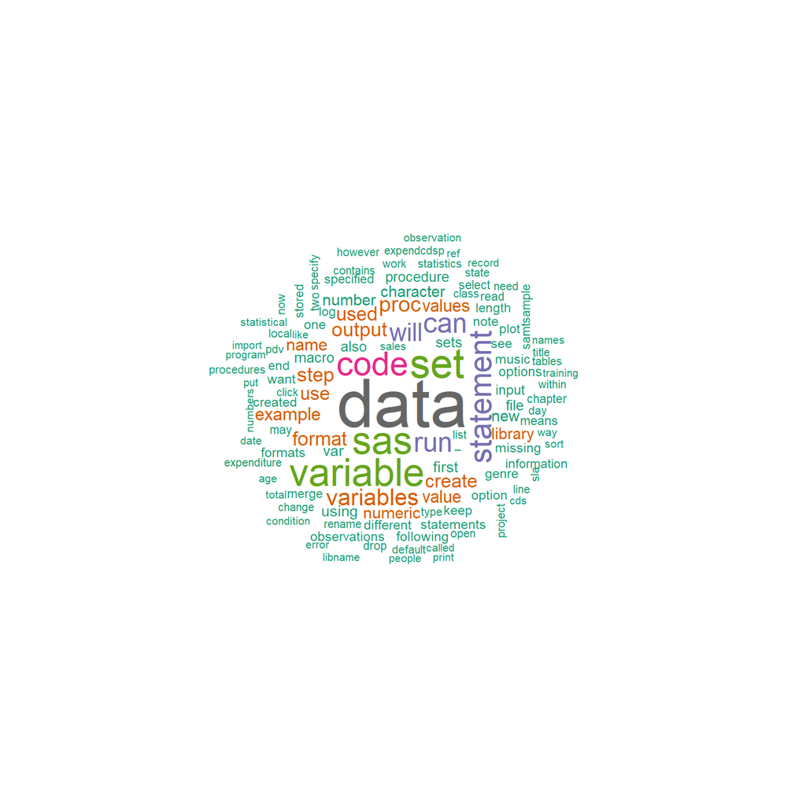

Figure 1: Word cloud R code plotting example

```r
# load packages
library(ctv)
library(tm)
library(SnowballC)
library(wordcloud)
library(RColorBrewer)

# load in the 'Intro to coding in SAS' document
cname <- file.path("inset path here")
docs <- Corpus(DirSource(cname))

# remove symbols, punctuation, stopwords etc.
for (j in seq(docs)) {docs[[j]] <- gsub("/"," ",docs[[j]])}
for (j in seq(docs)) {docs[[j]] <- gsub("@"," ",docs[[j]])}

docs <- tm_map(docs, tolower)
docs <- tm_map(docs, removeWords, stopwords("english"))
docs <- tm_map(docs, removeNumbers)
docs <- tm_map(docs, removePunctuation)
docs <- tm_map(docs, stripWhitespace)
docs <- tm_map(docs, PlainTextDocument)

# create structured data from the document
dtm <- DocumentTermMatrix(docs)

# create a matrix from the document, and a data frame of the words and frequencies
m <- as.matrix(dtm)
v <- sort(colSums(m), decreasing = TRUE)
words <- names(v)
d <- data.frame(word=words, freq=v)

# create the word cloud
wordcloud(d$word, d$freq, min.freq = 25, random.order = FALSE, colors =brewer.pal(8, "Dark2"))
```

### Adding a Figure from a file

```r
## matrix plot (the movie)

# generate pairs of x-y values
nx = 75
ny = 75
x = sample(x = 1:nx, size = 75, replace = TRUE)
y = seq(-1, -ny, length = 75)

# set graphical parameters
op = par(bg = "black", mar = c(0, 0.2, 0, 0.2))

# plot
plot(1:nx, seq(-1, -nx), type = "n", xlim = c(1, nx), ylim = c(-ny + 10, 1))
for (i in seq_along(x)){
  aux = sample(1:ny, 1)
  points(rep(x[i], aux), y[1:aux], pch = sample(letters, aux, replace = TRUE),
         col = hsv(0.35, 1, 1, runif(aux, 0.3)), cex = runif(aux, 0.3))
}
```

[output not shown]

Captions, size, alignment etc. of the figures can be controlled through code arguments around each image file

[figure not shown]

### Adding tables through code

Data can be added to a document simply by returning an object such as an array or frame, or it can be output in to a formattable table

```r
# returning an object
head(mtcars[, 1:7])
```

```
##                    mpg cyl disp  hp drat    wt  qsec
## Mazda RX4         21.0   6  160 110 3.90 2.620 16.46
## Mazda RX4 Wag     21.0   6  160 110 3.90 2.875 17.02
## Datsun 710        22.8   4  108  93 3.85 2.320 18.61
## Hornet 4 Drive    21.4   6  258 110 3.08 3.215 19.44
## Hornet Sportabout 18.7   8  360 175 3.15 3.440 17.02
## Valiant           18.1   6  225 105 2.76 3.460 20.22
```

```r
# HTML table
knitr::kable(head(mtcars[, 1:7]), caption = "Table 1: Example HTML table") %>% kable_styling()
```

Table 1: Example HTML table

|  | mpg | cyl | disp | hp | drat | wt | qsec |
| --- | --- | --- | --- | --- | --- | --- | --- |
| Mazda RX4 | 21.0 | 6 | 160 | 110 | 3.90 | 2.620 | 16.46 |
| Mazda RX4 Wag | 21.0 | 6 | 160 | 110 | 3.90 | 2.875 | 17.02 |
| Datsun 710 | 22.8 | 4 | 108 | 93 | 3.85 | 2.320 | 18.61 |
| Hornet 4 Drive | 21.4 | 6 | 258 | 110 | 3.08 | 3.215 | 19.44 |
| Hornet Sportabout | 18.7 | 8 | 360 | 175 | 3.15 | 3.440 | 17.02 |
| Valiant | 18.1 | 6 | 225 | 105 | 2.76 | 3.460 | 20.22 |

# Adding inline code and equations

### Inline code

Inline code can be written within a pair of backquotes , e.g. `insert inline code here`

### Simple inline formula

Inline equations can be written within a pair of dollar `$` signs using $\LaTeX$ syntax, e.g. $y = mx + c$

### Equations as a block

Equations can be written as a block within a pair of double dollar signs `$$` using $\LaTeX$ syntax, e.g.

$$\int_\Omega \nabla u \cdot \nabla v~dx = \int_\Omega fv~dx$$